# Beispiel für die Verwendung von eurostat und NUTS

Manfred Brill

# 1 Packages

Dieses Beispiel verwendet die folgenden Packages:

- tidyverse, insbesondere ggplot
- eurostat

Die Kartendaten werden online abgefragt, was beim ersten Ausführen zu einer Wartezeit führen kann. Anschließend werden die Daten im Cache von RMarkdown gehalten.

# 2 Quelle der Darstellung

Diese Darstellung ist aus einem Beispiel von Leo Lahti entnommen, das auf [https://github.com/ropengov/eurostat/blob/master/vignettes/website/maps.Rmd] zu finden ist. Wir verwenden den Quelltext im Abschnitt *Disposable income of private households by NUTS 2 regions at 1:60mln resolution using ggplot2*. Der Quelltext ist dort im Rmd-Format zu finden und wurde hier für eine bessere Verständlichkeit in mehrere Abschnitte aufgeteilt. Die Bezeichner und auch die Kommentare wurden nicht verändert! Um einen Eindruck von dem Vorgehen zu haben gibt es zusätzliches Ausgaben der tibbles und anderer Variablen.

# 3 Daten und Kartenmaterial

Als erstes fragen wir die statistischen Daten von Eurostat ab, die wir auf der Karte visualisieren möchten:

```r
dat <- get_eurostat("tgs00026", time_format = "raw", stringsAsFactors = FALSE) %>%
  # subsetting to year 2014 and NUTS-2 level
  dplyr::filter(time == 2014, nchar(geo) == 4) %>%
  # classifying the values the variable
  dplyr::mutate(cat = cut_to_classes(values))
```

```
Table tgs00026 cached at C:\Users\brill\AppData\Local\Temp\RtmpesM3N1/eurostat/tgs00026_raw_code_FF.rds
```

```r
glimpse(dat)
```

```
Rows: 247
Columns: 7
$ unit    <chr> "PPS_EU27_2020_HAB", "PPS_EU27_2020_HAB",~
$ direct  <chr> "BAL", "BAL", "BAL", "BAL", "BAL", "BAL",~
$ na_item <chr> "B6N", "B6N", "B6N", "B6N", "B6N", "B6N",~
$ geo     <chr> "AT11", "AT12", "AT13", "AT21", "AT22", "~
$ time    <chr> "2014", "2014", "2014", "2014", "2014", "~
$ values  <dbl> 19700, 20500, 19100, 19000, 19300, 19800,~
$ cat     <fct> 17 160 ~< 21 180, 17 160 ~< 21 180, 17 16~
```

Jetzt fragen wir die NUTS-Daten für die Karten ab. Das könnte man auch lokal machen, aber wir verändern den Quelltext nicht. Nach dem Laden der Karten-Daten wird ein *merge* der beiden Datensätze durchgeführt.

```r
# Download geospatial data from GISCO
geodata <- get_eurostat_geospatial(resolution = "60", nuts_level = "2", year = 2013)
```

[output not shown]

```r
geodata
```

```
Simple feature collection with 320 features and 8 fields
Geometry type: MULTIPOLYGON
Dimension:     XY
Bounding box:  xmin: -61.8 ymin: -21.4 xmax: 55.8 ymax: 71.1
Geodetic CRS:  WGS 84
First 10 features:
     id NUTS_ID LEVL_CODE CNTR_CODE            NAME_LATN
1  AT11    AT11         2        AT      Burgenland (AT)
2  AT12    AT12         2        AT     Niederösterreich
3  AT13    AT13         2        AT                 Wien
4  AT21    AT21         2        AT              Kärnten
5  AT22    AT22         2        AT           Steiermark
6  AT31    AT31         2        AT       Oberösterreich
7  AT32    AT32         2        AT             Salzburg
8  BE31    BE31         2        BE Prov. Brabant Wallon
```

[output cut: 24 more lines]

```r
# merge with attribute data with geodata
map_data <- inner_join(geodata, dat)
map_data
```

```
Simple feature collection with 201 features and 14 fields
Geometry type: MULTIPOLYGON
Dimension:     XY
Bounding box:  xmin: -25.9 ymin: 27.6 xmax: 34.6 ymax: 71.1
Geodetic CRS:  WGS 84
First 10 features:
     id NUTS_ID LEVL_CODE CNTR_CODE            NAME_LATN
1  AT11    AT11         2        AT      Burgenland (AT)
2  AT12    AT12         2        AT     Niederösterreich
3  AT13    AT13         2        AT                 Wien
4  AT21    AT21         2        AT              Kärnten
5  AT22    AT22         2        AT           Steiermark
6  AT31    AT31         2        AT       Oberösterreich
7  AT32    AT32         2        AT             Salzburg
8  BE31    BE31         2        BE Prov. Brabant Wallon
```

[output cut: 35 more lines]

Die Angabe zu *CRS* ist interessant. Der verwendete Code gibt an, dass wir auf die Koordinaten in der Karte mit Hilfe von Angaben in Grad zugreifen können.

# 4 Ausgabe der Karte mit ggplot

Jetzt können wir die Visualisierung mit *ggplot* durchführen, wir verwenden *geom_sf*.

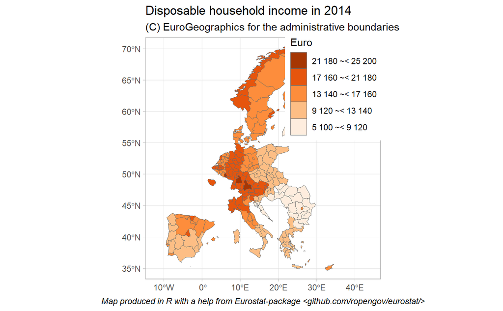

```r
ggplot(data=map_data) +
  geom_sf(aes(fill=cat),
          color="dim grey",
          size=.1) +
  coord_sf(
    xlim=c(-12,44),
    ylim=c(35,70)
  )  +
  scale_fill_brewer(palette = "Oranges") +
  guides(fill = guide_legend(reverse=T, title = "Euro")) +
  labs(title="Disposable household income in 2014",
       subtitle="(C) EuroGeographics for the administrative boundaries",
       caption="Map produced in R with a help from Eurostat-package <github.com/ropengov/eurostat/>") +
  theme_light() +
  theme(legend.position=c(.8,.8),
        plot.caption = element_text(hjust = 0.5,
                                    face = "italic"))

ggsave(filename="eurostatExample.png", plot=last_plot(),
       device="png",
       path="images/",
       width=16, height=16, units="cm")
```